# HR Predictive Analytics Project – Monitoring Turnover Risk

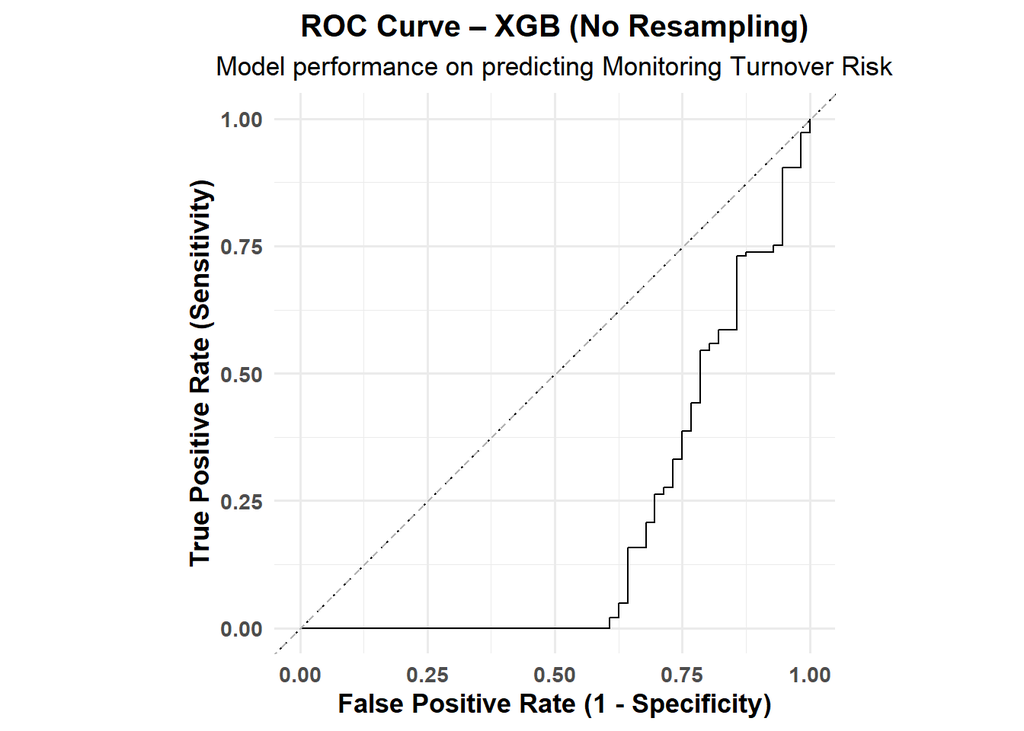

```r
# ROC Curve
roc_curve(xgb_preds_none, truth = Monitoring_Turnover_Risk, .pred_Yes) %>%
  autoplot() +
  geom_abline(linetype = "dashed", color = "gray70") +
  labs(
    title = "ROC Curve – XGB (No Resampling)",
    subtitle = "Model performance on predicting Monitoring Turnover Risk",
    x = "False Positive Rate (1 - Specificity)",
    y = "True Positive Rate (Sensitivity)"
  ) +
  theme_minimal(base_size = 13) +
  theme(
    plot.title = element_text(face = "bold", size = 15, hjust = 0.5),
    plot.subtitle = element_text(hjust = 0.5),
    axis.title = element_text(face = "bold"),
    axis.text = element_text(face = "bold")
  )
```

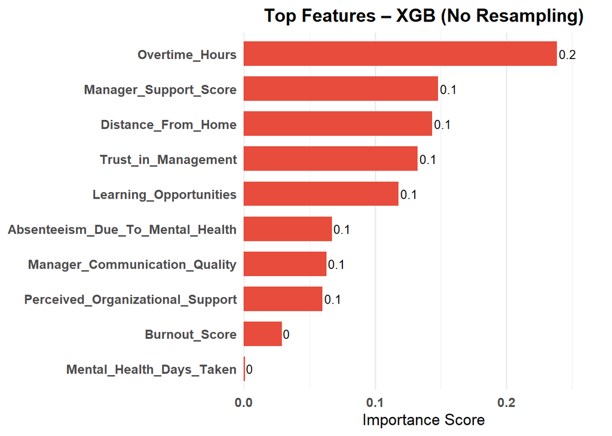

```r
# Variable Importance
xgb_fit_none %>%
  extract_fit_parsnip() %>%
  vi() %>%
  arrange(desc(Importance)) %>%
  slice_head(n = 15) %>%
  mutate(Variable = fct_reorder(Variable, Importance)) %>%
  ggplot(aes(x = Importance, y = Variable)) +
  geom_col(fill = "#E87461", width = 0.7) +
  geom_text(aes(label = round(Importance, 1)), hjust = -0.1, color = "black", size = 3.5) +
  scale_x_continuous(expand = expansion(mult = c(0, 0.15))) +
  labs(
    title = "Top Features – XGB (No Resampling)",
    x = "Importance Score", y = NULL
  ) +
  theme_minimal(base_size = 13) +
  theme(
    plot.title = element_text(face = "bold", hjust = 0.5, size = 15),
    axis.text = element_text(face = "bold"),
    panel.grid.major.y = element_blank()
  )
```

### 4.3 XGBoost - SMOTE

```r
# Create SMOTE Recipe
recipe_xgb_smote <- base_recipe %>%
  step_smote(Monitoring_Turnover_Risk)

# Build XGBoost Workflow with SMOTE
workflow_xgb_smote <- workflow() %>%
  add_model(xgb_model) %>%
  add_recipe(recipe_xgb_smote)

# Tune Hyperparameters with Cross-Validation
set.seed(42)
xgb_tuned_smote <- tune_grid(
  workflow_xgb_smote,
  resamples = mtr_folds,
  grid = 10,
  metrics = metric_set(accuracy, roc_auc)
)

# Select Best Parameters Based on ROC AUC
best_xgb_smote <- select_best(xgb_tuned_smote, metric = "roc_auc")

# Finalize Workflow with Best Parameters
final_xgb_workflow_smote <- finalize_workflow(workflow_xgb_smote, best_xgb_smote)

# Fit Final Model to Training Data
xgb_fit_smote <- fit(final_xgb_workflow_smote, data = mtr_train_data)

# Predict on Test Data
xgb_preds_smote <- predict(xgb_fit_smote, new_data = mtr_test_data, type = "prob") %>%
  bind_cols(predict(xgb_fit_smote, new_data = mtr_test_data)) %>%
  bind_cols(mtr_test_data %>% select(Monitoring_Turnover_Risk))
```

### 4.4 XGBoost - SMOTE - Peformance Metrics

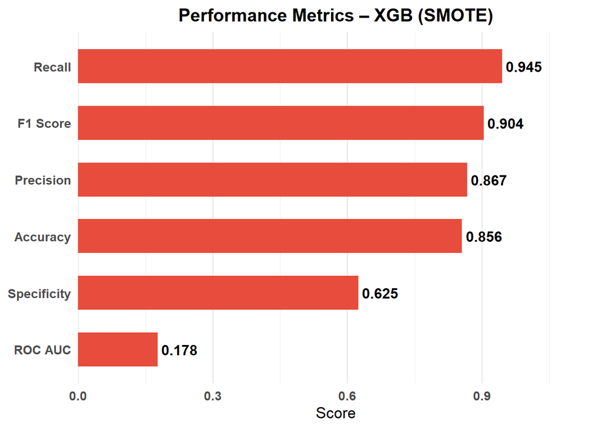

```r
# Metrics
xgb_smote_metrics <- all_metrics(xgb_preds_smote, truth = Monitoring_Turnover_Risk, estimate = .pred_class, .pred_Yes)

# Plot
xgb_smote_metrics %>%
  filter(.metric %in% c("accuracy", "precision", "recall", "f_meas", "spec", "roc_auc")) %>%
  mutate(.metric = factor(.metric,
                          levels = c("accuracy", "precision", "recall", "f_meas", "spec", "roc_auc"),
                          labels = c("Accuracy", "Precision", "Recall", "F1 Score", "Specificity", "ROC AUC"))) %>%
  ggplot(aes(x = .estimate, y = fct_reorder(.metric, .estimate))) +
  geom_col(fill = "#E74C3C", width = 0.6) +
  geom_text(aes(label = sprintf("%.3f", .estimate)),
            hjust = -0.1, color = "black", size = 4.2, fontface = "bold") +
  scale_x_continuous(limits = c(0, 1), expand = expansion(mult = c(0, 0.15))) +
  labs(
    title = "Performance Metrics – XGB (SMOTE)",
    x = "Score", y = NULL
  ) +
  theme_minimal(base_size = 13) +
  theme(
    plot.title = element_text(face = "bold", size = 15, hjust = 0.5),
    axis.text = element_text(face = "bold"),
    panel.grid.major.y = element_blank()
  )
```

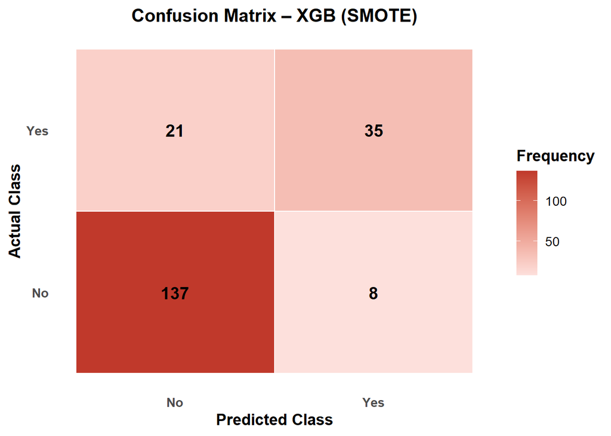

```r
# Confusion Matrix
cm_xgb_smote <- conf_mat(xgb_preds_smote, truth = Monitoring_Turnover_Risk, estimate = .pred_class)
cm_df_xgb_smote <- as.data.frame(cm_xgb_smote$table)

cm_df_xgb_smote$Truth <- factor(cm_df_xgb_smote$Truth, levels = c("Yes", "No"))
cm_df_xgb_smote$Prediction <- factor(cm_df_xgb_smote$Prediction, levels = c("No", "Yes"))

ggplot(cm_df_xgb_smote, aes(x = Prediction, y = Truth, fill = Freq)) +
  geom_tile(color = "white", linewidth = 0.5) +
  geom_text(aes(label = Freq), color = "black", size = 5, fontface = "bold") +
  scale_fill_gradient(low = "#fde0dc", high = "#c0392b", name = "Frequency") +
  scale_y_discrete(limits = rev) +
  labs(
    title = "Confusion Matrix – XGB (SMOTE)",
    x = "Predicted Class",
    y = "Actual Class"
  ) +
  theme_minimal(base_size = 13) +
  theme(
    plot.title = element_text(face = "bold", hjust = 0.5, size = 15),
    axis.title = element_text(face = "bold"),
    axis.text = element_text(face = "bold"),
    legend.title = element_text(face = "bold"),
    panel.grid = element_blank()
  )
```

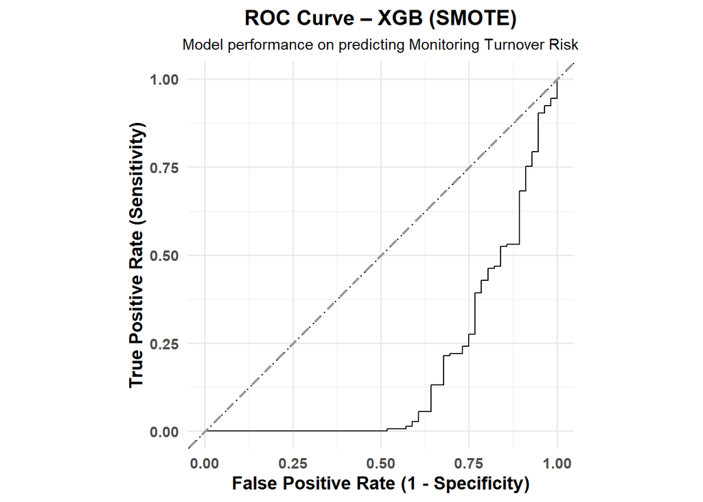

```r
# ROC Curve
roc_curve(xgb_preds_smote, truth = Monitoring_Turnover_Risk, .pred_Yes) %>%
  autoplot() +
  geom_abline(linetype = "dashed", color = "gray60", size = 0.8) +
  labs(
    title = "ROC Curve – XGB (SMOTE)",
    subtitle = "Model performance on predicting Monitoring Turnover Risk",
    x = "False Positive Rate (1 - Specificity)",
    y = "True Positive Rate (Sensitivity)"
  ) +
  theme_minimal(base_size = 13) +
  theme(
    plot.title = element_text(face = "bold", size = 15, hjust = 0.5),
    plot.subtitle = element_text(hjust = 0.5, size = 11),
    axis.title = element_text(face = "bold"),
    axis.text = element_text(face = "bold")
  )
```

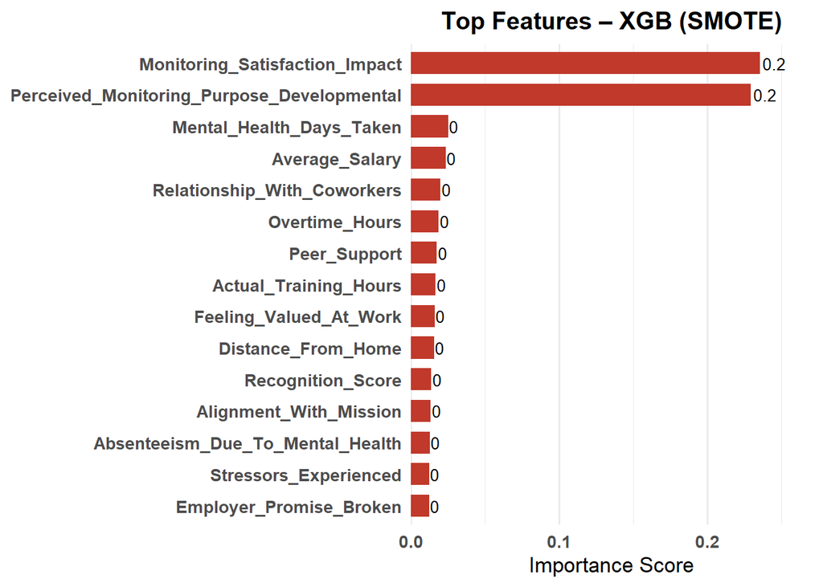

```r
# Variable Importance
vip_xgb_smote <- xgb_fit_smote %>%
  extract_fit_parsnip() %>%
  vi() %>%
  arrange(desc(Importance)) %>%
  slice_head(n = 15) %>%
  mutate(Variable = fct_reorder(Variable, Importance))

ggplot(vip_xgb_smote, aes(x = Importance, y = Variable)) +
  geom_col(fill = "#C0392B", width = 0.7) +
  geom_text(aes(label = round(Importance, 1)), hjust = -0.1, color = "black", size = 3.5) +
  scale_x_continuous(expand = expansion(mult = c(0, 0.15))) +
  labs(
    title = "Top Features – XGB (SMOTE)",
    x = "Importance Score", y = NULL
  ) +
  theme_minimal(base_size = 13) +
  theme(
    plot.title = element_text(face = "bold", hjust = 0.5, size = 15),
    axis.text = element_text(face = "bold"),
    panel.grid.major.y = element_blank()
  )
```

### 4.5 XGBoost - Upsampling

```r
# Create Recipe from Base
recipe_xgb_upsample <- base_recipe %>%
  step_upsample(Monitoring_Turnover_Risk)

# Workflow with XGBoost
workflow_xgb_upsample <- workflow() %>%
  add_model(xgb_model) %>%
  add_recipe(recipe_xgb_upsample)

# Tune the XGBoost model with cross-validation
set.seed(42)
xgb_tuned_upsample <- tune_grid(
  workflow_xgb_upsample,
  resamples = mtr_folds,
  grid = 10,
  metrics = metric_set(accuracy, roc_auc)
  )

# Select Best model by AUC
best_xgb_upsample <- select_best(xgb_tuned_upsample, metric = "roc_auc")

# Final workflow with best XGBoost model
final_xgb_workflow_upsample <- finalize_workflow(workflow_xgb_upsample, best_xgb_upsample)

# Fit to training data
xgb_fit_upsample <- fit(final_xgb_workflow_upsample, data = mtr_train_data)

# Predict on test data
xgb_preds_upsample <- predict(xgb_fit_upsample, new_data = mtr_test_data, type = "prob") %>%
  bind_cols(predict(xgb_fit_upsample, new_data = mtr_test_data)) %>%
  bind_cols(mtr_test_data %>% select(Monitoring_Turnover_Risk))
```

### 4.6 XGBoost - Upsampling - Performance Metrics

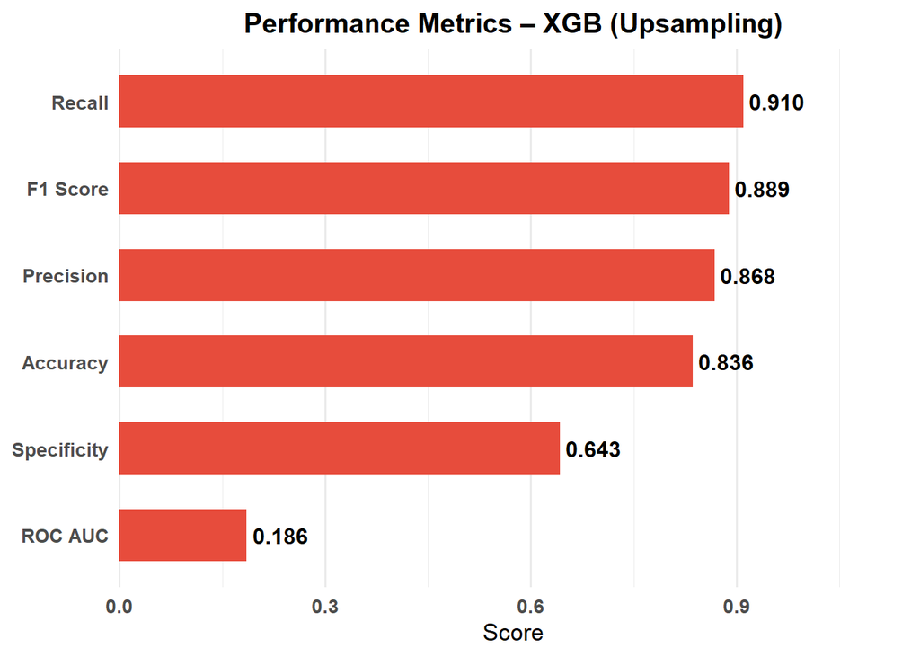

```r
# Metrics
xgb_upsample_metrics <- all_metrics(xgb_preds_upsample, truth = Monitoring_Turnover_Risk, estimate = .pred_class, .pred_Yes)

# Plot
xgb_upsample_metrics %>%
  filter(.metric %in% c("accuracy", "precision", "recall", "f_meas", "spec", "roc_auc"),
         !is.na(.estimate)) %>%
  mutate(.metric = factor(.metric,
                          levels = c("accuracy", "precision", "recall", "f_meas", "spec", "roc_auc"),
                          labels = c("Accuracy", "Precision", "Recall", "F1 Score", "Specificity", "ROC AUC"))) %>%
  ggplot(aes(x = .estimate, y = fct_reorder(.metric, .estimate, .na_rm = TRUE))) +
  geom_col(fill = "#E74C3C", width = 0.6) +
  geom_text(aes(label = sprintf("%.3f", .estimate)),
            hjust = -0.1, color = "black", size = 4.2, fontface = "bold") +
  scale_x_continuous(limits = c(0, 1), expand = expansion(mult = c(0, 0.15))) +
  labs(
    title = "Performance Metrics – XGB (Upsampling)",
    x = "Score", y = NULL
  ) +
  theme_minimal(base_size = 13) +
  theme(
    plot.title = element_text(face = "bold", size = 15, hjust = 0.5),
    axis.text = element_text(face = "bold"),
    panel.grid.major.y = element_blank()
  )
```

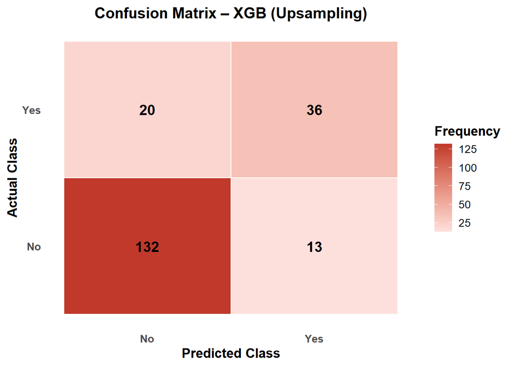

```r
# Confusion Matrix
cm_xgb_upsample <- conf_mat(xgb_preds_upsample, truth = Monitoring_Turnover_Risk, estimate = .pred_class)
cm_df_xgb_upsample <- as.data.frame(cm_xgb_upsample$table)

cm_df_xgb_upsample$Truth <- factor(cm_df_xgb_upsample$Truth, levels = c("Yes", "No"))
cm_df_xgb_upsample$Prediction <- factor(cm_df_xgb_upsample$Prediction, levels = c("No", "Yes"))

ggplot(cm_df_xgb_upsample, aes(x = Prediction, y = Truth, fill = Freq)) +
  geom_tile(color = "white", linewidth = 0.5) +
  geom_text(aes(label = Freq), color = "black", size = 5, fontface = "bold") +
  scale_fill_gradient(low = "#fde0dc", high = "#c0392b", name = "Frequency") +
  scale_y_discrete(limits = rev) +
  labs(
    title = "Confusion Matrix – XGB (Upsampling)",
    x = "Predicted Class",
    y = "Actual Class"
  ) +
  theme_minimal(base_size = 13) +
  theme(
    plot.title = element_text(face = "bold", hjust = 0.5, size = 15),
    axis.title = element_text(face = "bold"),
    axis.text = element_text(face = "bold"),
    legend.title = element_text(face = "bold"),
    panel.grid = element_blank()
  )
```

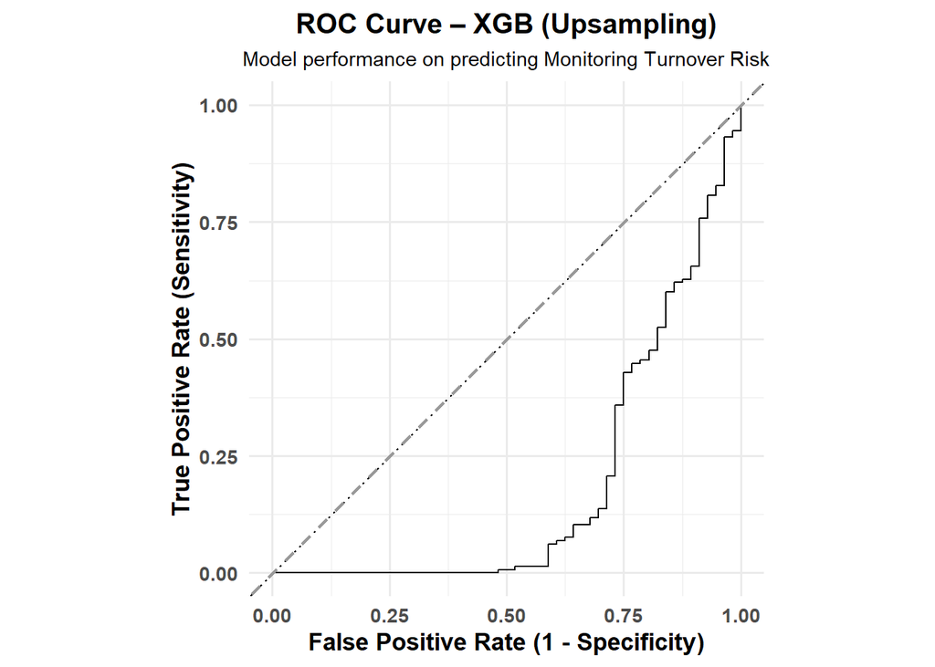

```r
# ROC Curve
roc_curve(xgb_preds_upsample, truth = Monitoring_Turnover_Risk, .pred_Yes) %>%
  autoplot() +
  geom_abline(linetype = "dashed", color = "gray60", size = 0.8) +
  labs(
    title = "ROC Curve – XGB (Upsampling)",
    subtitle = "Model performance on predicting Monitoring Turnover Risk",
    x = "False Positive Rate (1 - Specificity)",
    y = "True Positive Rate (Sensitivity)"
  ) +
  theme_minimal(base_size = 13) +
  theme(
    plot.title = element_text(face = "bold", size = 15, hjust = 0.5),
    plot.subtitle = element_text(hjust = 0.5, size = 11),
    axis.title = element_text(face = "bold"),
    axis.text = element_text(face = "bold")
  )
```

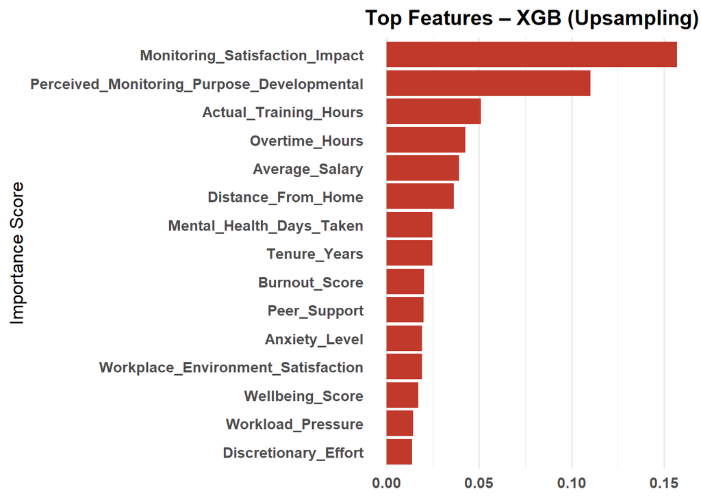

```r
# Variable Importance
# Step 1: Prep the recipe used for training
baked_train <- prep(recipe_xgb_upsample, training = mtr_train_data) %>%
  bake(new_data = NULL)

# Step 2: Get feature names from preprocessed data (after dummy variables)
feature_names <- colnames(baked_train %>% select(-Monitoring_Turnover_Risk))

# Step 3: Extract booster
xgb_booster_upsample <- extract_fit_engine(xgb_fit_upsample)

# Step 4: Plot with feature names
vip::vip(
  object = xgb_booster_upsample,
  num_features = 15,
  geom = "col",
  feature_names = feature_names,
  aesthetics = list(fill = "#C0392B")
) +
  labs(
    title = "Top Features – XGB (Upsampling)",
    x = "Importance Score", y = NULL
  ) +
  theme_minimal(base_size = 13) +
  theme(
    plot.title = element_text(face = "bold", hjust = 0.5, size = 15),
    axis.text = element_text(face = "bold"),
    panel.grid.major.y = element_blank()
  )
```

### 4.7 XGBoost - Downsampling

```r
# Create Recipe from Base
recipe_xgb_downsample <- base_recipe %>%
  step_downsample(Monitoring_Turnover_Risk)

# Workflow with XGBoost
workflow_xgb_downsample <- workflow() %>%
  add_model(xgb_model) %>%
  add_recipe(recipe_xgb_downsample)

# Tune the RF model with cross-validation
set.seed(42)
xgb_tuned_downsample <- tune_grid(
  workflow_xgb_downsample,
  resamples = mtr_folds,
  grid = 10,
  metrics = metric_set(accuracy, roc_auc)
  )

# Select Best model by AUC
best_xgb_downsample <- select_best(xgb_tuned_downsample, metric = "roc_auc")

# Final workflow with best XGBoost model
final_xgb_workflow_downsample <- finalize_workflow(workflow_xgb_downsample, best_xgb_downsample)

# Fit to training data
xgb_fit_downsample <- fit(final_xgb_workflow_downsample, data = mtr_train_data)

# Predict on test data
xgb_preds_downsample <- predict(xgb_fit_downsample, new_data = mtr_test_data, type = "prob") %>%
  bind_cols(predict(xgb_fit_downsample, new_data = mtr_test_data)) %>%
  bind_cols(mtr_test_data %>% select(Monitoring_Turnover_Risk))
```

### 4.8 XGBoost - Downsampling - Performance Metrics

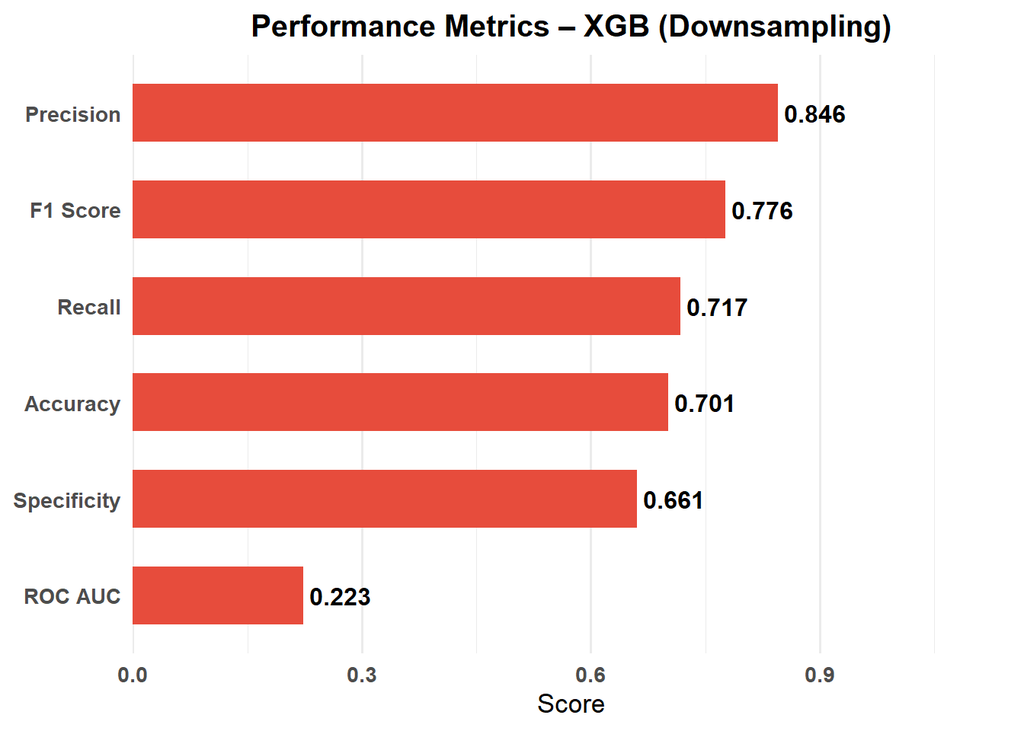

```r
# Metrics
xgb_downsample_metrics <- all_metrics(xgb_preds_downsample, truth = Monitoring_Turnover_Risk, estimate = .pred_class, .pred_Yes)

# Print
xgb_downsample_metrics %>%
  filter(.metric %in% c("accuracy", "precision", "recall", "f_meas", "spec", "roc_auc")) %>%
  mutate(.metric = factor(.metric,
                          levels = c("accuracy", "precision", "recall", "f_meas", "spec", "roc_auc"),
                          labels = c("Accuracy", "Precision", "Recall", "F1 Score", "Specificity", "ROC AUC"))) %>%
  ggplot(aes(x = .estimate, y = fct_reorder(.metric, .estimate))) +
  geom_col(fill = "#E74C3C", width = 0.6) +
  geom_text(aes(label = sprintf("%.3f", .estimate)),
            hjust = -0.1, color = "black", size = 4.2, fontface = "bold") +
  scale_x_continuous(limits = c(0, 1), expand = expansion(mult = c(0, 0.15))) +
  labs(
    title = "Performance Metrics – XGB (Downsampling)",
    x = "Score", y = NULL
  ) +
  theme_minimal(base_size = 13) +
  theme(
    plot.title = element_text(face = "bold", size = 15, hjust = 0.5),
    axis.text = element_text(face = "bold"),
    panel.grid.major.y = element_blank()
  )
```

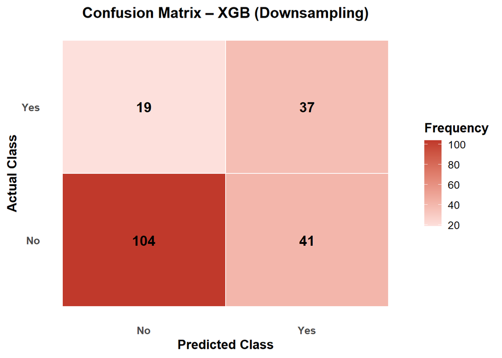

```r
# Confusion Matrix
cm_xgb_down <- conf_mat(xgb_preds_downsample, truth = Monitoring_Turnover_Risk, estimate = .pred_class)
cm_df_xgb_down <- as.data.frame(cm_xgb_down$table)

cm_df_xgb_down$Truth <- factor(cm_df_xgb_down$Truth, levels = c("Yes", "No"))
cm_df_xgb_down$Prediction <- factor(cm_df_xgb_down$Prediction, levels = c("No", "Yes"))

ggplot(cm_df_xgb_down, aes(x = Prediction, y = Truth, fill = Freq)) +
  geom_tile(color = "white", linewidth = 0.5) +
  geom_text(aes(label = Freq), color = "black", size = 5, fontface = "bold") +
  scale_fill_gradient(low = "#fde0dc", high = "#c0392b", name = "Frequency") +
  scale_y_discrete(limits = rev) +
  labs(
    title = "Confusion Matrix – XGB (Downsampling)",
    x = "Predicted Class",
    y = "Actual Class"
  ) +
  theme_minimal(base_size = 13) +
  theme(
    plot.title = element_text(face = "bold", hjust = 0.5, size = 15),
    axis.title = element_text(face = "bold"),
    axis.text = element_text(face = "bold"),
    legend.title = element_text(face = "bold"),
    panel.grid = element_blank()
  )
```

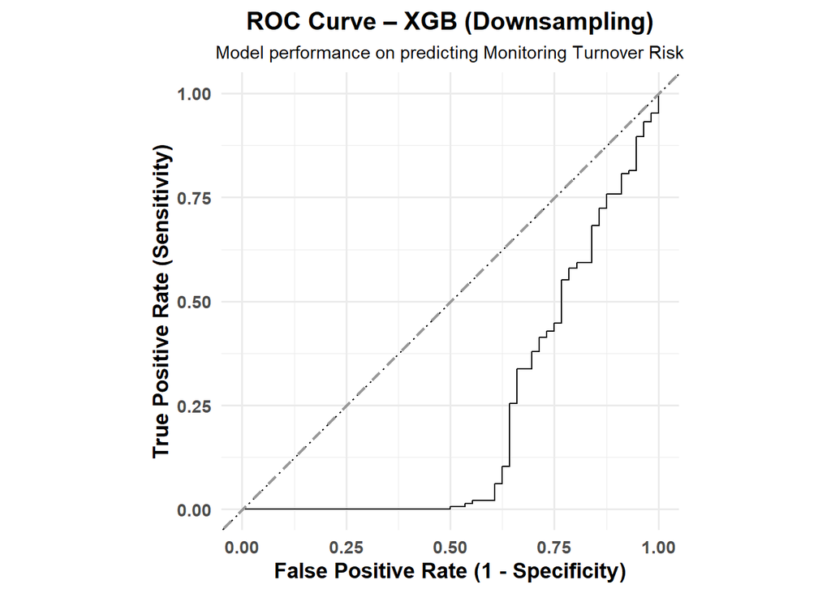

```r
# ROC Curve
roc_curve(xgb_preds_downsample, truth = Monitoring_Turnover_Risk, .pred_Yes) %>%
  autoplot() +
  geom_abline(linetype = "dashed", color = "gray60", size = 0.8) +
  labs(
    title = "ROC Curve – XGB (Downsampling)",
    subtitle = "Model performance on predicting Monitoring Turnover Risk",
    x = "False Positive Rate (1 - Specificity)",
    y = "True Positive Rate (Sensitivity)"
  ) +
  theme_minimal(base_size = 13) +
  theme(
    plot.title = element_text(face = "bold", size = 15, hjust = 0.5),
    plot.subtitle = element_text(hjust = 0.5, size = 11),
    axis.title = element_text(face = "bold"),
    axis.text = element_text(face = "bold")
  )
```

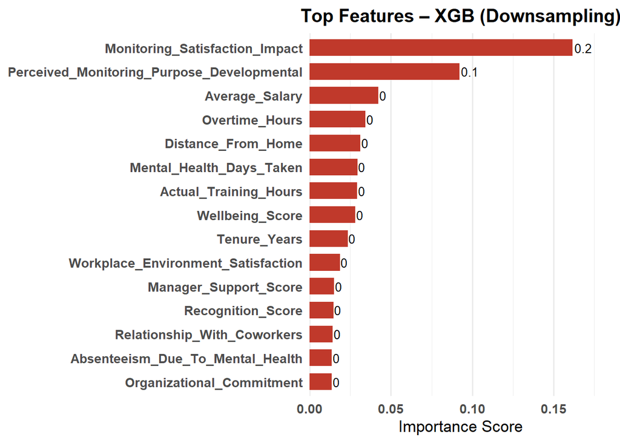

```r
# Variable Importance
xgb_fit_downsample %>%
  extract_fit_parsnip() %>%
  vi() %>%
  arrange(desc(Importance)) %>%
  slice_head(n = 15) %>%
  mutate(Variable = fct_reorder(Variable, Importance)) %>%
  ggplot(aes(x = Importance, y = Variable)) +
  geom_col(fill = "#C0392B", width = 0.7) +
  geom_text(aes(label = round(Importance, 1)), hjust = -0.1, color = "black", size = 3.5) +
  scale_x_continuous(expand = expansion(mult = c(0, 0.15))) +
  labs(
    title = "Top Features – XGB (Downsampling)",
    x = "Importance Score", y = NULL
  ) +
  theme_minimal(base_size = 13) +
  theme(
    plot.title = element_text(face = "bold", hjust = 0.5, size = 15),
    axis.text = element_text(face = "bold"),
    panel.grid.major.y = element_blank()
  )
```

### 4.9 Results Table for XGBoost (Monitoring Turnover Risk)

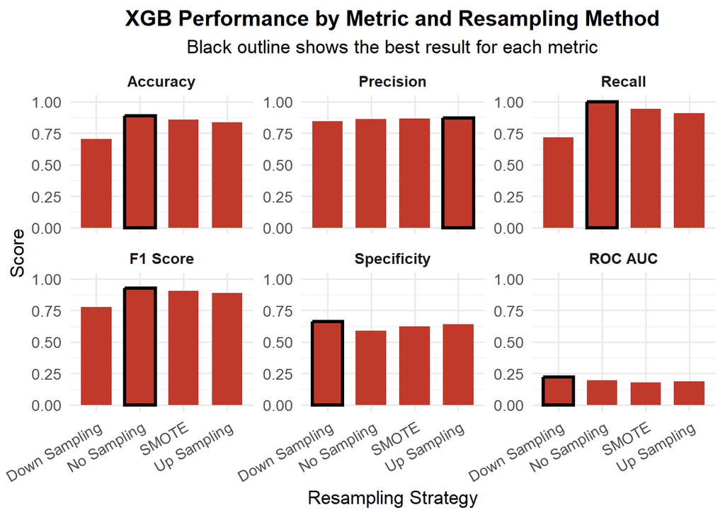

```r
# Combine metrics and label with model names
xgb_results_table <- bind_rows(
  all_metrics(xgb_preds_none, truth = Monitoring_Turnover_Risk, estimate = .pred_class, .pred_Yes) %>%
    mutate(model = "XGB - No Resampling"),
  all_metrics(xgb_preds_smote, truth = Monitoring_Turnover_Risk, estimate = .pred_class, .pred_Yes) %>%
    mutate(model = "XGB - SMOTE"),
  all_metrics(xgb_preds_upsample, truth = Monitoring_Turnover_Risk, estimate = .pred_class, .pred_Yes) %>%
    mutate(model = "XGB - Up Sampling"),
  all_metrics(xgb_preds_downsample, truth = Monitoring_Turnover_Risk, estimate = .pred_class, .pred_Yes) %>%
    mutate(model = "XGB - Down Sampling")
)

# Reshape and clean
xgb_results_long <- xgb_results_table %>%
  filter(.metric %in% c("accuracy", "precision", "recall", "f_meas", "spec", "roc_auc")) %>%
  mutate(
    Resample = case_when(
      str_detect(model, "No Resampling") ~ "No Sampling",
      str_detect(model, "SMOTE") ~ "SMOTE",
      str_detect(model, "Up Sampling") ~ "Up Sampling",
      str_detect(model, "Down Sampling") ~ "Down Sampling",
      TRUE ~ NA_character_
    ),
    Metric = factor(.metric,
                    levels = c("accuracy", "precision", "recall", "f_meas", "spec", "roc_auc"),
                    labels = c("Accuracy", "Precision", "Recall", "F1 Score", "Specificity", "ROC AUC"))
  ) %>%
  filter(!is.na(Resample), !is.na(.estimate))

# Identify top score per metric
highlight_xgb <- xgb_results_long %>%
  group_by(Metric) %>%
  filter(.estimate == max(.estimate, na.rm = TRUE)) %>%
  mutate(is_best = TRUE)

# Merge with main table
xgb_results_highlight <- xgb_results_long %>%
  left_join(highlight_xgb %>% select(Resample, Metric, is_best), by = c("Resample", "Metric")) %>%
  mutate(is_best = ifelse(is.na(is_best), FALSE, is_best))

# Plot
ggplot(xgb_results_highlight, aes(x = Resample, y = .estimate, fill = Metric)) +
  geom_col(width = 0.7, color = NA) +
  geom_col(
    data = subset(xgb_results_highlight, is_best),
    aes(x = Resample, y = .estimate),
    fill = NA,
    color = "black",
    linewidth = 1.2,
    width = 0.7
  ) +
  facet_wrap(~ Metric, nrow = 2, scales = "free_y") +
  scale_y_continuous(limits = c(0, 1)) +
  scale_fill_manual(values = rep("#C0392B", 6)) +
  labs(
    title = "XGB Performance by Metric and Resampling Method",
    subtitle = "Black outline shows the best result for each metric",
    x = "Resampling Strategy", y = "Score"
  ) +
  theme_minimal(base_size = 13) +
  theme(
    plot.title = element_text(face = "bold", size = 15, hjust = 0.5),
    plot.subtitle = element_text(hjust = 0.5),
    axis.text.x = element_text(angle = 30, hjust = 1),
    strip.text = element_text(face = "bold"),
    legend.position = "none"
  )
```

### 4.10 XGBoost – Turnover Risk Modeling Summary

XGBoost delivered **high-performing classification results** with strong precision, recall, and F1 scores across most sampling techniques. It consistently captured at-risk employees well, though like other models, it struggled with **calibrated probability estimates**, as reflected in modest ROC AUC scores. Notably, **No Resampling achieved perfect recall**, while **Downsampling delivered the best ROC AUC and specificity**, highlighting varied tradeoffs by sampling strategy.

- **No Resampling** delivered **perfect recall (1.000)** and strong overall metrics including **F1 score (0.927)**, **accuracy (0.886)**, and **precision (0.863)**. However, **ROC AUC was low (0.197)**, indicating limited ability to rank risk probabilities effectively.
- **SMOTE** produced high **recall (0.945)** and **F1 score (0.904)** with strong **precision (0.867)**. **Specificity improved to 0.625**, but **ROC AUC declined slightly to 0.178**, continuing the trend of poor calibration despite high classification scores.
- **Upsampling** maintained excellent performance with **recall (0.910)** and **F1 score (0.889)**, while achieving the **highest specificity (0.643)** among oversampling methods. **ROC AUC was modest at 0.186**.
- **Downsampling** had slightly lower **recall (0.717)** and **F1 score (0.776)**, but delivered the **best ROC AUC (0.223)** and strong **specificity (0.661)**. This method reduced overfitting and improved the model’s probability ranking capability — a distinct advantage over other sampling methods.

XGBoost showed excellent classification metrics across all sampling methods, particularly with **No Resampling** and **SMOTE** for recall and F1. However, if **probability calibration or risk ranking is a priority**, **Downsampling emerged as the best option** due to its superior ROC AUC and specificity. All ROC AUC values remained below **0.25**, highlighting continued challenges in probability-based prediction.

## 5 Monitoring Turnover Risk with Naive Bayes

### 5.1 Naive Bayes - No Resampling

```r
# Define Naive Bayes Model
nb_model <- naive_Bayes() %>%
  set_engine("naivebayes") %>%
  set_mode("classification")

# Build Workflow
workflow_nb_none <- workflow() %>%
  add_model(nb_model) %>%
  add_recipe(base_recipe)

# 10-Fold Cross-Validation on Training Data
set.seed(42)
nb_cv_results <- fit_resamples(
  workflow_nb_none,
  resamples = mtr_folds,
  metrics = metric_set(accuracy, precision, recall, f_meas, yardstick::spec, roc_auc)
)

# Fit Final Model to Full Training Data
nb_fit_none <- fit(workflow_nb_none, data = mtr_train_data)

# Predict on Test Data
nb_preds_none <- predict(nb_fit_none, new_data = mtr_test_data, type = "prob") %>%
  bind_cols(predict(nb_fit_none, new_data = mtr_test_data)) %>%
  bind_cols(mtr_test_data %>% select(Monitoring_Turnover_Risk))
```

### 5.2 Naive Bayes - No Resampling - Performance Metrics

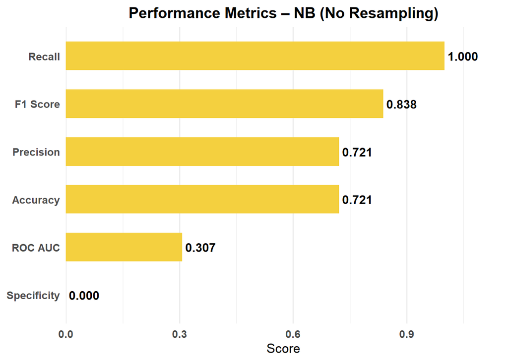

```r
# Metrics
nb_none_metrics <- all_metrics(nb_preds_none, truth = Monitoring_Turnover_Risk, estimate = .pred_class, .pred_Yes)

# Plot
nb_none_metrics %>%
  filter(.metric %in% c("accuracy", "precision", "recall", "f_meas", "spec", "roc_auc")) %>%
  mutate(.metric = factor(.metric,
                          levels = c("accuracy", "precision", "recall", "f_meas", "spec", "roc_auc"),
                          labels = c("Accuracy", "Precision", "Recall", "F1 Score", "Specificity", "ROC AUC"))) %>%
  ggplot(aes(x = .estimate, y = fct_reorder(.metric, .estimate))) +
  geom_col(fill = "#F4D03F", width = 0.6) +
  geom_text(aes(label = sprintf("%.3f", .estimate)), hjust = -0.1, color = "black", size = 4.2, fontface = "bold") +
  scale_x_continuous(limits = c(0, 1), expand = expansion(mult = c(0, 0.15))) +
  labs(
    title = "Performance Metrics – NB (No Resampling)",
    x = "Score", y = NULL
  ) +
  theme_minimal(base_size = 13) +
  theme(plot.title = element_text(face = "bold", hjust = 0.5, size = 15),
        axis.text = element_text(face = "bold"),
        panel.grid.major.y = element_blank())
```

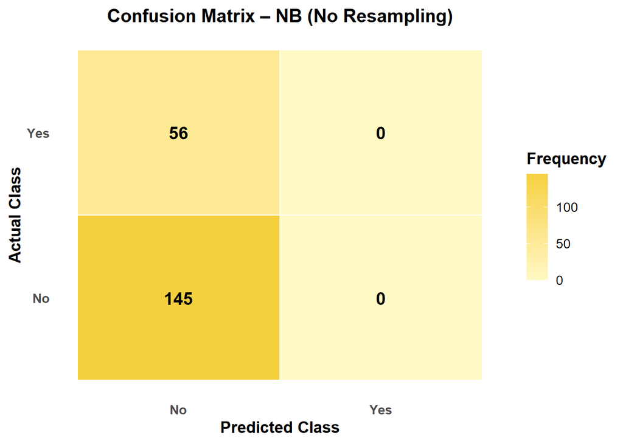

```r
# Confusion Matrix
cm_nb_none <- conf_mat(nb_preds_none, truth = Monitoring_Turnover_Risk, estimate = .pred_class)
cm_df_nb_none <- as.data.frame(cm_nb_none$table)
cm_df_nb_none$Truth <- factor(cm_df_nb_none$Truth, levels = c("Yes", "No"))
cm_df_nb_none$Prediction <- factor(cm_df_nb_none$Prediction, levels = c("No", "Yes"))

ggplot(cm_df_nb_none, aes(x = Prediction, y = Truth, fill = Freq)) +
  geom_tile(color = "white", linewidth = 0.5) +
  geom_text(aes(label = Freq), color = "black", size = 5, fontface = "bold") +
  scale_fill_gradient(low = "#FFF9C4", high = "#F4D03F", name = "Frequency") +
  scale_y_discrete(limits = rev) +
  labs(title = "Confusion Matrix – NB (No Resampling)",
       x = "Predicted Class", y = "Actual Class") +
  theme_minimal(base_size = 13) +
  theme(plot.title = element_text(face = "bold", hjust = 0.5, size = 15),
        axis.title = element_text(face = "bold"),
        axis.text = element_text(face = "bold"),
        legend.title = element_text(face = "bold"),
        panel.grid = element_blank())
```

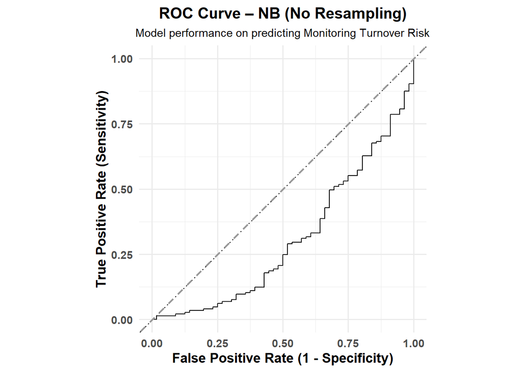

```r
# Roc
roc_curve(nb_preds_none, truth = Monitoring_Turnover_Risk, .pred_Yes) %>%
  autoplot() +
  geom_abline(linetype = "dashed", color = "gray60", size = 0.8) +
  labs(title = "ROC Curve – NB (No Resampling)",
       subtitle = "Model performance on predicting Monitoring Turnover Risk",
       x = "False Positive Rate (1 - Specificity)",
       y = "True Positive Rate (Sensitivity)") +
  theme_minimal(base_size = 13) +
  theme(plot.title = element_text(face = "bold", hjust = 0.5, size = 15),
        plot.subtitle = element_text(hjust = 0.5, size = 11),
        axis.title = element_text(face = "bold"),
        axis.text = element_text(face = "bold"))
```

### 5.3 Naive Bayes - Smote

```r
# Create Upsampling Recipe
recipe_nb_smote <- base_recipe %>%
  step_smote(Monitoring_Turnover_Risk)

# Build Workflow with Upsampling
workflow_nb_smote <- workflow() %>%
  add_model(nb_model) %>%
  add_recipe(recipe_nb_smote)

# 10-Fold Cross-Validation
set.seed(42)
nb_cv_smote <- fit_resamples(
  workflow_nb_smote,
  resamples = mtr_folds,
  metrics = metric_set(accuracy, precision, recall, f_meas, yardstick::spec, roc_auc)
)

# Final Fit on Full Training Data
nb_fit_smote <- fit(workflow_nb_smote, data = mtr_train_data)

# Predict on Test Set
nb_preds_smote <- predict(nb_fit_smote, new_data = mtr_test_data, type = "prob") %>%
  bind_cols(predict(nb_fit_smote, new_data = mtr_test_data)) %>%
  bind_cols(mtr_test_data %>% select(Monitoring_Turnover_Risk))
```

### 5.4 Naive Bayes - SMOTE - Performance Metrics

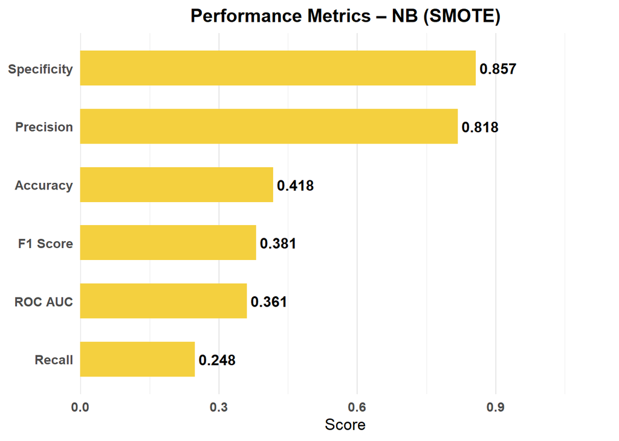

```r
# Metrics
nb_smote_metrics <- all_metrics(nb_preds_smote, truth = Monitoring_Turnover_Risk, estimate = .pred_class, .pred_Yes)

# Print
nb_smote_metrics %>%
  filter(.metric %in% c("accuracy", "precision", "recall", "f_meas", "spec", "roc_auc")) %>%
  mutate(.metric = factor(.metric,
                          levels = c("accuracy", "precision", "recall", "f_meas", "spec", "roc_auc"),
                          labels = c("Accuracy", "Precision", "Recall", "F1 Score", "Specificity", "ROC AUC"))) %>%
  ggplot(aes(x = .estimate, y = fct_reorder(.metric, .estimate))) +
  geom_col(fill = "#F4D03F", width = 0.6) +
  geom_text(aes(label = sprintf("%.3f", .estimate)), hjust = -0.1, color = "black", size = 4.2, fontface = "bold") +
  scale_x_continuous(limits = c(0, 1), expand = expansion(mult = c(0, 0.15))) +
  labs(title = "Performance Metrics – NB (SMOTE)",
       x = "Score", y = NULL) +
  theme_minimal(base_size = 13) +
  theme(plot.title = element_text(face = "bold", hjust = 0.5, size = 15),
        axis.text = element_text(face = "bold"),
        panel.grid.major.y = element_blank())
```

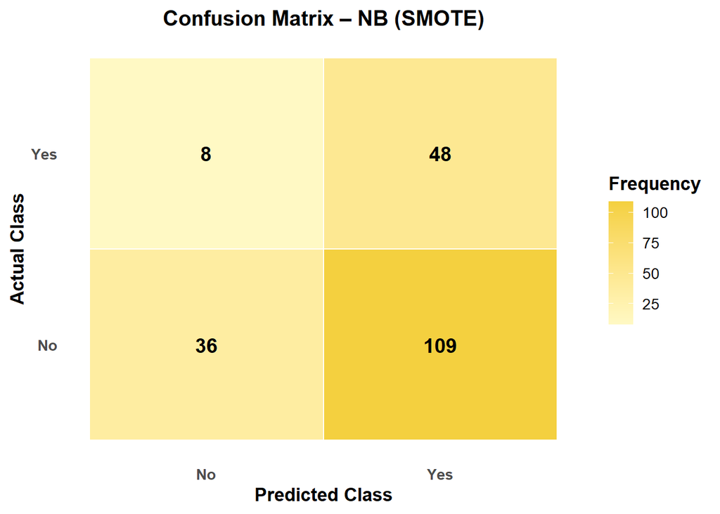

```r
# Confusion Matrix
cm_nb_smote <- conf_mat(nb_preds_smote, truth = Monitoring_Turnover_Risk, estimate = .pred_class)
cm_df_nb_smote <- as.data.frame(cm_nb_smote$table)
cm_df_nb_smote$Truth <- factor(cm_df_nb_smote$Truth, levels = c("Yes", "No"))
cm_df_nb_smote$Prediction <- factor(cm_df_nb_smote$Prediction, levels = c("No", "Yes"))

ggplot(cm_df_nb_smote, aes(x = Prediction, y = Truth, fill = Freq)) +
  geom_tile(color = "white", linewidth = 0.5) +
  geom_text(aes(label = Freq), color = "black", size = 5, fontface = "bold") +
  scale_fill_gradient(low = "#FFF9C4", high = "#F4D03F", name = "Frequency") +
  scale_y_discrete(limits = rev) +
  labs(title = "Confusion Matrix – NB (SMOTE)",
       x = "Predicted Class", y = "Actual Class") +
  theme_minimal(base_size = 13) +
  theme(plot.title = element_text(face = "bold", hjust = 0.5, size = 15),
        axis.title = element_text(face = "bold"),
        axis.text = element_text(face = "bold"),
        legend.title = element_text(face = "bold"),
        panel.grid = element_blank())
```

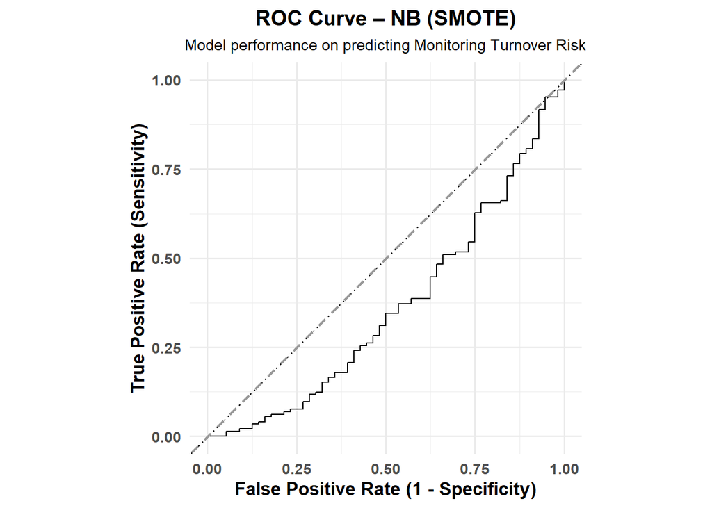

```r
# Roc
roc_curve(nb_preds_smote, truth = Monitoring_Turnover_Risk, .pred_Yes) %>%
  autoplot() +
  geom_abline(linetype = "dashed", color = "gray60", size = 0.8) +
  labs(title = "ROC Curve – NB (SMOTE)",
       subtitle = "Model performance on predicting Monitoring Turnover Risk",
       x = "False Positive Rate (1 - Specificity)",
       y = "True Positive Rate (Sensitivity)") +
  theme_minimal(base_size = 13) +
  theme(plot.title = element_text(face = "bold", hjust = 0.5, size = 15),
        plot.subtitle = element_text(hjust = 0.5, size = 11),
        axis.title = element_text(face = "bold"),
        axis.text = element_text(face = "bold"))
```

### 5.5 Naive Bayes - Upsampling

```r
# Create Upsampling Recipe
recipe_nb_upsample <- base_recipe %>%
  step_upsample(Monitoring_Turnover_Risk)

# Build Workflow with Upsampling
workflow_nb_upsample <- workflow() %>%
  add_model(nb_model) %>%
  add_recipe(recipe_nb_upsample)

# 10-Fold Cross-Validation
set.seed(42)
nb_cv_upsample <- fit_resamples(
  workflow_nb_upsample,
  resamples = mtr_folds,
  metrics = metric_set(accuracy, precision, recall, f_meas, yardstick::spec, roc_auc)
)

# Final Fit on Full Training Data
nb_fit_upsample <- fit(workflow_nb_upsample, data = mtr_train_data)

# Predict on Test Set
nb_preds_upsample <- predict(nb_fit_upsample, new_data = mtr_test_data, type = "prob") %>%
  bind_cols(predict(nb_fit_upsample, new_data = mtr_test_data)) %>%
  bind_cols(mtr_test_data %>% select(Monitoring_Turnover_Risk))
```

### 5.6 Naive Bayes - Upsampling - Performance Metrics

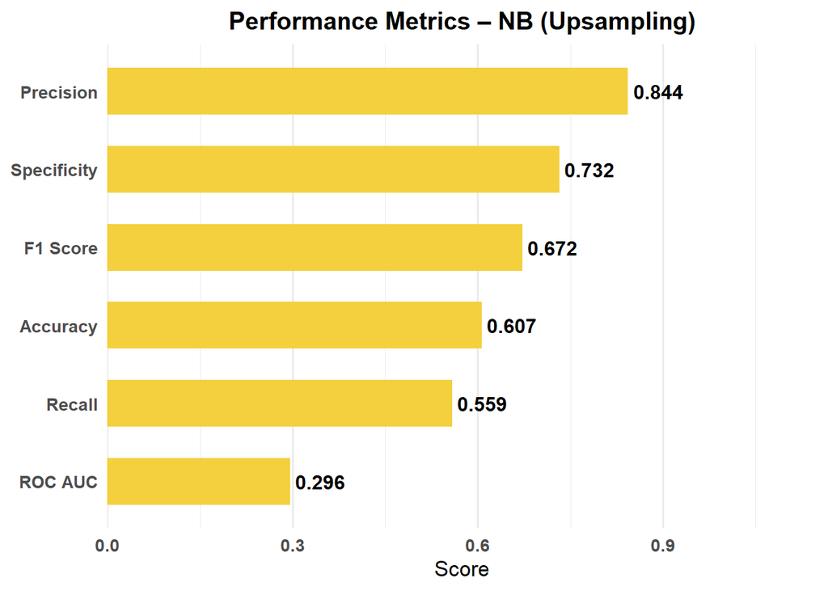

```r
# Metrics
nb_upsample_metrics <- all_metrics(nb_preds_upsample, truth = Monitoring_Turnover_Risk, estimate = .pred_class, .pred_Yes)

# Print
nb_upsample_metrics %>%
  filter(.metric %in% c("accuracy", "precision", "recall", "f_meas", "spec", "roc_auc")) %>%
  mutate(.metric = factor(.metric,
                          levels = c("accuracy", "precision", "recall", "f_meas", "spec", "roc_auc"),
                          labels = c("Accuracy", "Precision", "Recall", "F1 Score", "Specificity", "ROC AUC"))) %>%
  ggplot(aes(x = .estimate, y = fct_reorder(.metric, .estimate))) +
  geom_col(fill = "#F4D03F", width = 0.6) +
  geom_text(aes(label = sprintf("%.3f", .estimate)), hjust = -0.1, color = "black", size = 4.2, fontface = "bold") +
  scale_x_continuous(limits = c(0, 1), expand = expansion(mult = c(0, 0.15))) +
  labs(title = "Performance Metrics – NB (Upsampling)",
       x = "Score", y = NULL) +
  theme_minimal(base_size = 13) +
  theme(plot.title = element_text(face = "bold", hjust = 0.5, size = 15),
        axis.text = element_text(face = "bold"),
        panel.grid.major.y = element_blank())
```

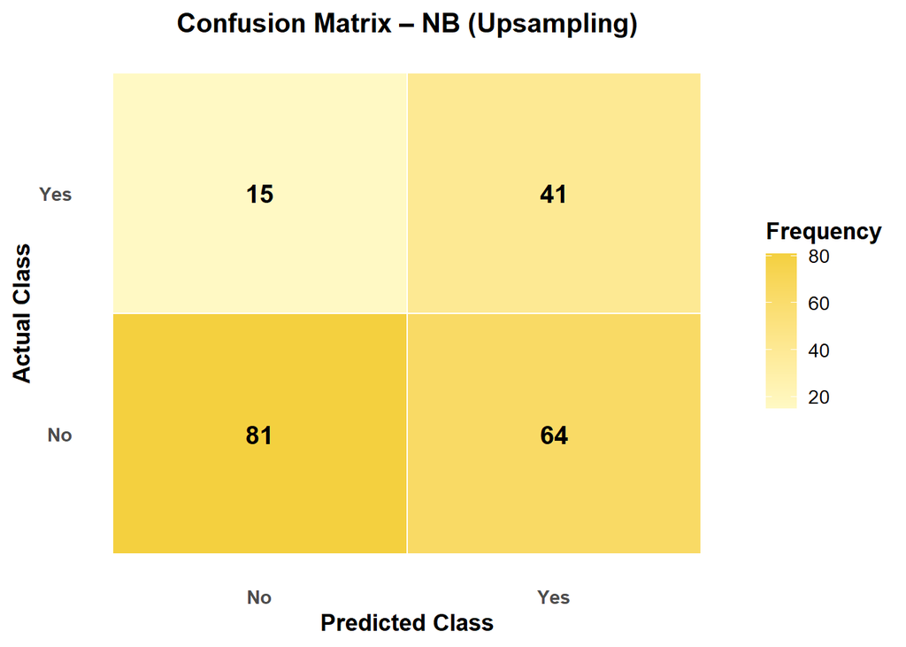

```r
# Confusion Matrix
cm_nb_upsample <- conf_mat(nb_preds_upsample, truth = Monitoring_Turnover_Risk, estimate = .pred_class)
cm_df_nb_upsample <- as.data.frame(cm_nb_upsample$table)
cm_df_nb_upsample$Truth <- factor(cm_df_nb_upsample$Truth, levels = c("Yes", "No"))
cm_df_nb_upsample$Prediction <- factor(cm_df_nb_upsample$Prediction, levels = c("No", "Yes"))

ggplot(cm_df_nb_upsample, aes(x = Prediction, y = Truth, fill = Freq)) +
  geom_tile(color = "white", linewidth = 0.5) +
  geom_text(aes(label = Freq), color = "black", size = 5, fontface = "bold") +
  scale_fill_gradient(low = "#FFF9C4", high = "#F4D03F", name = "Frequency") +
  scale_y_discrete(limits = rev) +
  labs(title = "Confusion Matrix – NB (Upsampling)",
       x = "Predicted Class", y = "Actual Class") +
  theme_minimal(base_size = 13) +
  theme(plot.title = element_text(face = "bold", hjust = 0.5, size = 15),
        axis.title = element_text(face = "bold"),
        axis.text = element_text(face = "bold"),
        legend.title = element_text(face = "bold"),
        panel.grid = element_blank())
```

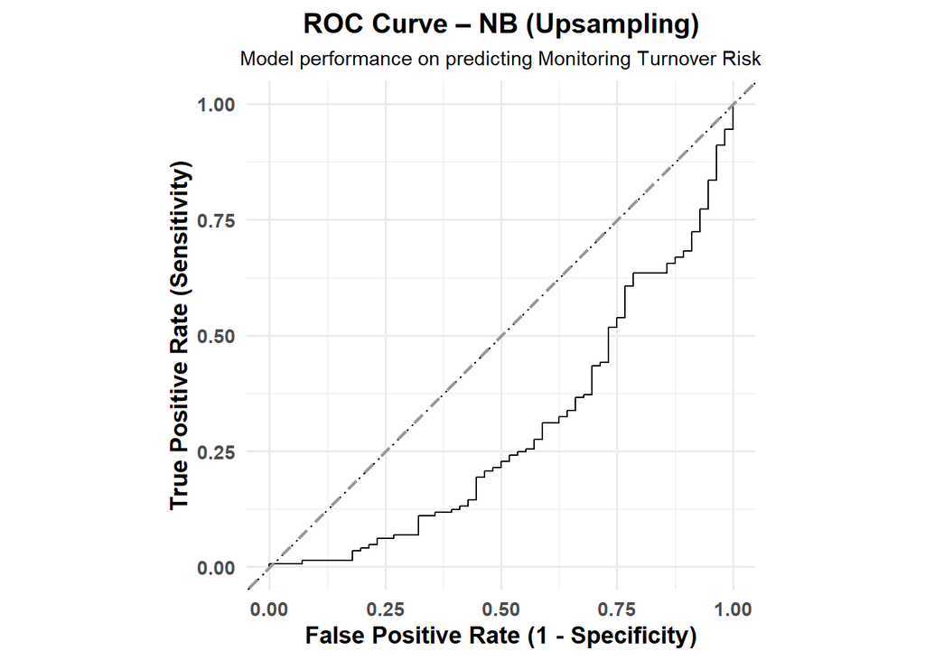

```r
# Roc
roc_curve(nb_preds_upsample, truth = Monitoring_Turnover_Risk, .pred_Yes) %>%
  autoplot() +
  geom_abline(linetype = "dashed", color = "gray60", size = 0.8) +
  labs(title = "ROC Curve – NB (Upsampling)",
       subtitle = "Model performance on predicting Monitoring Turnover Risk",
       x = "False Positive Rate (1 - Specificity)",
       y = "True Positive Rate (Sensitivity)") +
  theme_minimal(base_size = 13) +
  theme(plot.title = element_text(face = "bold", hjust = 0.5, size = 15),
        plot.subtitle = element_text(hjust = 0.5, size = 11),
        axis.title = element_text(face = "bold"),
        axis.text = element_text(face = "bold"))
```

### 5.7 Naive Bayes - Downsampling

```r
# Create Downsampling Recipe
recipe_nb_downsample <- base_recipe %>%
  step_downsample(Monitoring_Turnover_Risk)

# Build Workflow with Downsampling
workflow_nb_downsample <- workflow() %>%
  add_model(nb_model) %>%
  add_recipe(recipe_nb_downsample)

# 10-Fold Cross-Validation
set.seed(42)
nb_cv_downsample <- fit_resamples(
  workflow_nb_downsample,
  resamples = mtr_folds,
  metrics = metric_set(accuracy, precision, recall, f_meas, yardstick::spec, roc_auc)
)

# Fit Final Model on Full Training Data
nb_fit_downsample <- fit(workflow_nb_downsample, data = mtr_train_data)

# Predict on Test Set
nb_preds_downsample <- predict(nb_fit_downsample, new_data = mtr_test_data, type = "prob") %>%
  bind_cols(predict(nb_fit_downsample, new_data = mtr_test_data)) %>%
  bind_cols(mtr_test_data %>% select(Monitoring_Turnover_Risk))
```

### 5.8 Naive Bayes - Downsampling - Performance Metrics

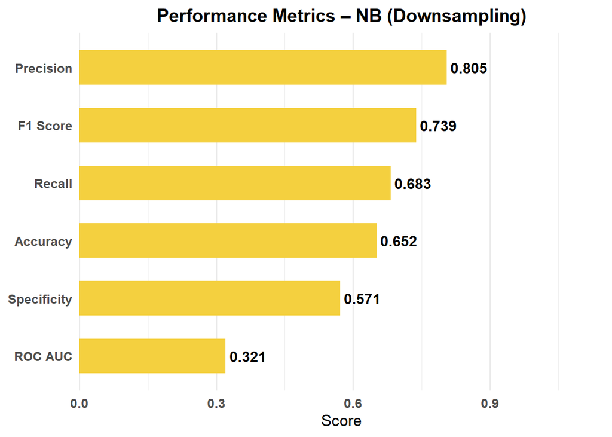

```r
# Metrics
nb_downsample_metrics <- all_metrics(nb_preds_downsample, truth = Monitoring_Turnover_Risk, estimate = .pred_class, .pred_Yes)

# Print
nb_downsample_metrics %>%
  filter(.metric %in% c("accuracy", "precision", "recall", "f_meas", "spec", "roc_auc")) %>%
  mutate(.metric = factor(.metric,
                          levels = c("accuracy", "precision", "recall", "f_meas", "spec", "roc_auc"),
                          labels = c("Accuracy", "Precision", "Recall", "F1 Score", "Specificity", "ROC AUC"))) %>%
  ggplot(aes(x = .estimate, y = fct_reorder(.metric, .estimate))) +
  geom_col(fill = "#F4D03F", width = 0.6) +
  geom_text(aes(label = sprintf("%.3f", .estimate)), hjust = -0.1, color = "black", size = 4.2, fontface = "bold") +
  scale_x_continuous(limits = c(0, 1), expand = expansion(mult = c(0, 0.15))) +
  labs(title = "Performance Metrics – NB (Downsampling)",
       x = "Score", y = NULL) +
  theme_minimal(base_size = 13) +
  theme(plot.title = element_text(face = "bold", hjust = 0.5, size = 15),
        axis.text = element_text(face = "bold"),
        panel.grid.major.y = element_blank())
```

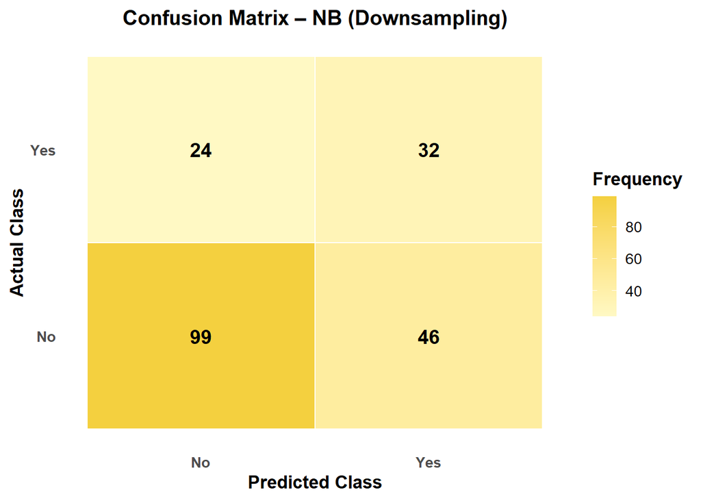

```r
# Confusion Marix
cm_nb_downsample <- conf_mat(nb_preds_downsample, truth = Monitoring_Turnover_Risk, estimate = .pred_class)
cm_df_nb_downsample <- as.data.frame(cm_nb_downsample$table)
cm_df_nb_downsample$Truth <- factor(cm_df_nb_downsample$Truth, levels = c("Yes", "No"))
cm_df_nb_downsample$Prediction <- factor(cm_df_nb_downsample$Prediction, levels = c("No", "Yes"))

ggplot(cm_df_nb_downsample, aes(x = Prediction, y = Truth, fill = Freq)) +
  geom_tile(color = "white", linewidth = 0.5) +
  geom_text(aes(label = Freq), color = "black", size = 5, fontface = "bold") +
  scale_fill_gradient(low = "#FFF9C4", high = "#F4D03F", name = "Frequency") +
  scale_y_discrete(limits = rev) +
  labs(title = "Confusion Matrix – NB (Downsampling)",
       x = "Predicted Class", y = "Actual Class") +
  theme_minimal(base_size = 13) +
  theme(plot.title = element_text(face = "bold", hjust = 0.5, size = 15),
        axis.title = element_text(face = "bold"),
        axis.text = element_text(face = "bold"),
        legend.title = element_text(face = "bold"),
        panel.grid = element_blank())
```

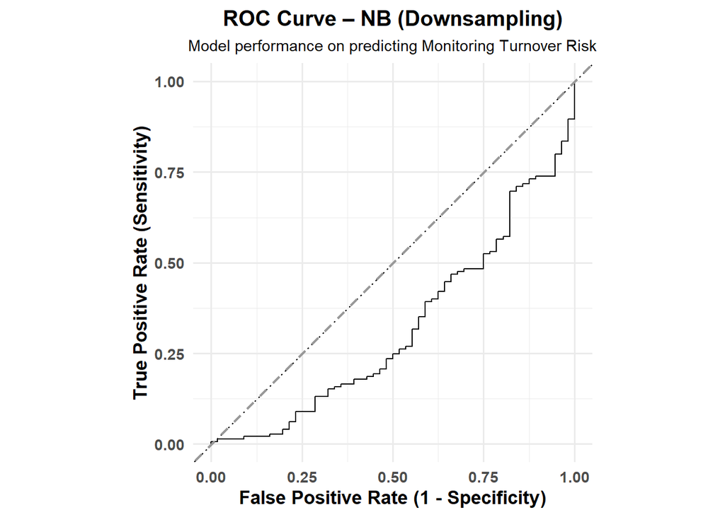

```r
# Roc
roc_curve(nb_preds_downsample, truth = Monitoring_Turnover_Risk, .pred_Yes) %>%
  autoplot() +
  geom_abline(linetype = "dashed", color = "gray60", size = 0.8) +
  labs(title = "ROC Curve – NB (Downsampling)",
       subtitle = "Model performance on predicting Monitoring Turnover Risk",
       x = "False Positive Rate (1 - Specificity)",
       y = "True Positive Rate (Sensitivity)") +
  theme_minimal(base_size = 13) +
  theme(plot.title = element_text(face = "bold", hjust = 0.5, size = 15),
        plot.subtitle = element_text(hjust = 0.5, size = 11),
        axis.title = element_text(face = "bold"),
        axis.text = element_text(face = "bold"))
```